# Assignment 4: Water Quality in Rivers

Keith Bollt

## OVERVIEW

This exercise accompanies the lessons in Hydrologic Data Analysis on water quality in rivers.

## Directions

1. Change “Student Name” on line 3 (above) with your name.
2. Work through the steps, **creating code and output** that fulfill each instruction.
3. Be sure to **answer the questions** in this assignment document.
4. When you have completed the assignment, **Knit** the text and code into a single HTML file.
5. After Knitting, submit the completed exercise (HTML file) to the dropbox in Sakai. Add your last name into the file name (e.g., “A04_Chamberlin.html”) prior to submission.

The completed exercise is due on 25 September 2019 at 9:00 am.

## Setup

1. Verify your working directory is set to the R project file,
2. Load the tidyverse, dataRetrieval, cowplot, xts and dygraphs packages.
3. Set your ggplot theme (can be theme_classic or something else)

```r
getwd()
```

```
## [1] "Z:/Hydrologic_Data_Analysis2"
```

```r
#install.packages("tidyverse")
#install.packages("dataRetrieval")
#install.packages("cowplot")
#install.packages("xts")
#install.packages("dygraphs")

library(tidyverse)
library(dataRetrieval)
library(cowplot)
library(xts)
library(dygraphs)

theme_set(theme_classic())
```

## Hypoxia

This assignment will look at another measure of water quality - oxygen concentration. Though not directly important for human health, oxygen in the water column is very important for aquatic life, and so is considered a measure of water quality. Hypoxia (low oxygen) has many different definitions. For this assignment, we will use 2 mg/L O<sub>2</sub> as our cut-off.

4. Import the oxygen water quality data from New Hope Creek at Blands (using `readNWISqw()`, site code `02097314`, parameter code `00300`). Make a data frame called `O2.dat` that includes only the Date and O<sub>2</sub> concentration values. Give your data frame understandable column names.

```r
data.raw <- readNWISqw(siteNumbers = c("02097314"),
                     parameterCd = c("00300"),
                     startDate = "",
                     endDate = "")

o2.dat <- data.raw %>%
  select(Date = sample_dt,
         O2_Concentration = result_va)
```

5. Create a ggplot of oxygen concentrations over time. Include a horizonal line at 2 mg/l to show the hypoxia cutoff.

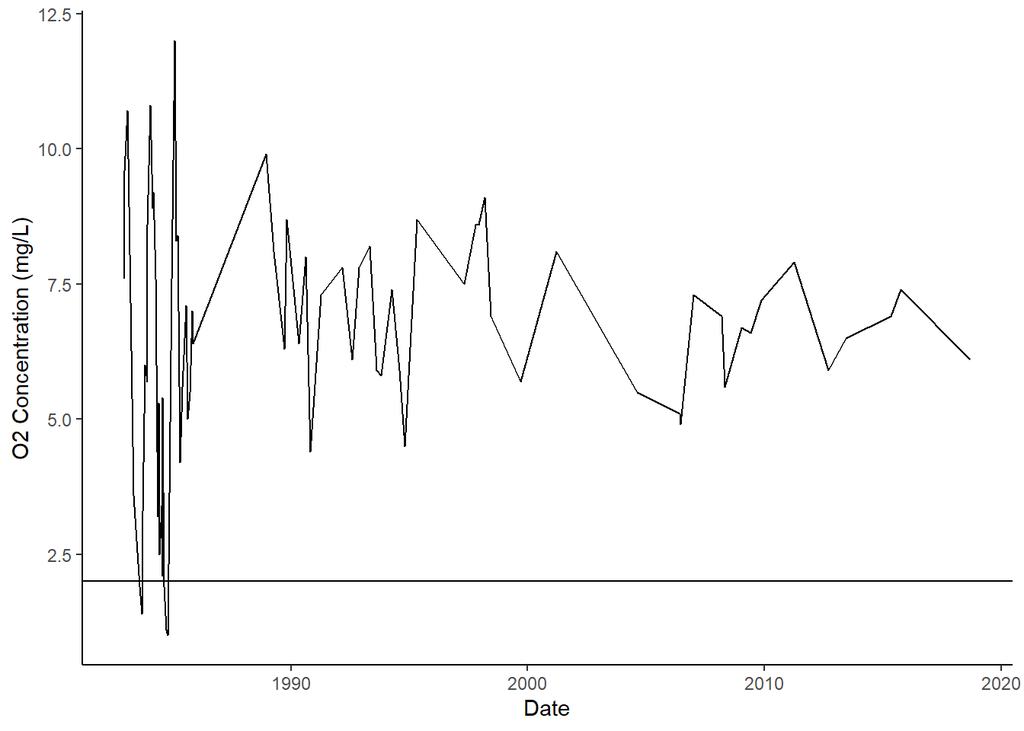

```r
variableInfo <- attr(data.raw, "variableInfo")

o2_timeseries <- ggplot(o2.dat, aes(x = Date, y = O2_Concentration))+
  geom_line()+
  labs(y = "O2 Concentration (mg/L)")+
  geom_hline(yintercept = 2)

print(o2_timeseries)
```

6. What do you notice about the frequency of hypoxia over time?

## Nutrients

7. Often times hypoxia is associated with high nutrient concentrations, because abundant nutrients promote biomass growth which increases respiration and depletes oxygen concentrations in the water (remember how oxygen concentrations were very low in the hypolimnion from the Physical Properties of Lakes week). Create a new data frame, called `nutrients.dat` with total nitrogen (parameter code `00600`) and total phosphorus (parameter code `00665`) data from the USGS. Your data frame should have 3 columns, `Date`, `TotalNitrogen_mgl-N`, and `TotalPhosphorus_mgl-P`.

```r
nutrients.raw <-
  readNWISqw(siteNumbers = c("02097314"),
                     parameterCd = c("00600", "00665"),
                     startDate = "",
                     endDate = "")

nutrients.mediumrare <- nutrients.raw %>%
  select(Date = sample_dt,
         Sample_Time = sample_tm,   #One date had two observations at different times of the day; my dataframe has
         #four columns, R wouldn't let me delete the sample time column.
         Parameter = parm_cd,
         Value = result_va)  %>%
  group_by(Date, Parameter) %>%
  summarize(Value = mean(Value)) %>%
  spread(key = Parameter, value = Value) %>%
  rename(TotalNitrogen_mgl_N = '00600',
         TotalPhosphorus_mgl_P = '00665')
```

8. Create two ggplots stacked with cowplot that show nutrient concentrations over time.

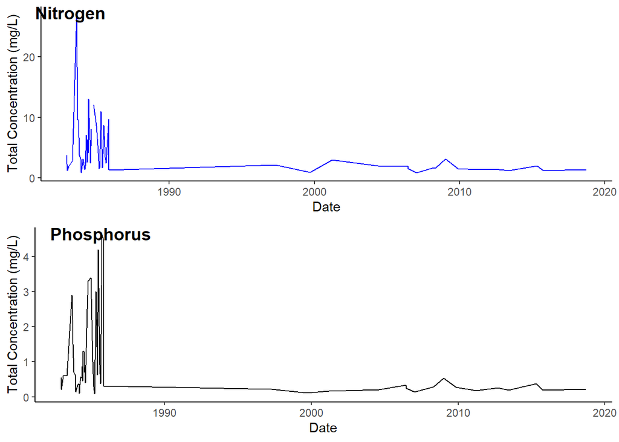

```r
N_concentrationplot <- ggplot(nutrients.mediumrare, aes(x = Date, y = TotalNitrogen_mgl_N))+
  geom_line(color = "Blue")+
  labs(y = "Total Concentration (mg/L)")

P_concentrationplot <- ggplot(nutrients.mediumrare, aes(x = Date, y = TotalPhosphorus_mgl_P))+
  geom_line()+
  labs(y = "Total Concentration (mg/L)")

Nutrientplot <-
  plot_grid(N_concentrationplot, P_concentrationplot, ncol = 1, labels = c('Nitrogen', 'Phosphorus'))
print(Nutrientplot)
```

9. What do these plots tell you about nutrient concentrations over time? How might this relate to your previous plot of hypoxia events?

## Discharge and Temperature

10. Turbulent flow in rivers mixes oxygen into the water column. As discharge decreases, water moves slower, and oxygen diffuses slower into the water from the atmosphere. Download and reformat the daily discharge data for New Hope Creek (function `readNWISdv()`, site `02097314`, parameter `00060`).

```r
dischargedata.raw <- readNWISdv(siteNumbers = c("02097314"),
                     parameterCd = c("00060"),
                     startDate = "",
                     endDate = "")

Dischargedata <- dischargedata.raw %>%
  select(site_no = site_no ,
        Date = Date,
         Discharge = X_00060_00003,
         Approval_Code = X_00060_00003_cd)
```

11. Create a dygraph of discharge and oxygen concentrations. You should have discharge on the y axis and oxygen concentration on the y2 axis. Set your y-axes limits so that they don’t change as you zoom in and out. (hint: use `dyAxis(..., valueRange = c(0, 6500))` for discharge & `dyAxis(..., valueRange = c(0, 13))` for oxygen).

```r
Total_Oxygen <- with(o2.dat, xts(x = O2_Concentration, order.by = Date))
Discharge <- with(Dischargedata, xts(x = Discharge, order.by = Date))

DyDat_HW <- cbind(Total_Oxygen, Discharge)

dygraph(DyDat_HW) %>%
  dySeries("Total_Oxygen", axis = "y2") %>%
  dyAxis(name = "y", label = "Discharge (cfs)", valueRange = c(0, 6500)) %>%
  dyAxis(name = "y2", label = "Total O2 (mg/L)", valueRange = c(0, 13)) %>%
  dyRangeSelector()
```

[interactive chart not shown]

12. Do hypoxic events happen in the wet or the dry season? How many days after storm events (of at least 100 cfs) do they occur?

> The dry season, for the most part. I see it in as little as two weeks after a storm in the summer of 1984, but it could be even less time than that; there isn’t a high enough frequency of data collection to know for sure.
13. Temperature also impacts the solubility of oxygen in water. More oxygen can dissolve when temperatures are *lower*. How would you analyze the effects of temperature on dissolved oxygen concentrations? What data would you need? How would you separate the effects of temperature from the effects of flow?

> To compare temperature and dissolved oxygen, you would need to obtain water temperature data for New Hope Creek. A good way to compare the two variables is with a dygraph similar to the discharge-oxygen graph, but substituting temperature for discharge. You would have to control for flow somehow, because high flows can help mix oxygen into the water and help it dissolve more rapidly. Maybe filter out flows above 100 cfs (100 cfs may even be too high), and assume that lower flows have a negligible effect on ability of water to absorb oxygen.
14. What do you think is the biggest driver of hypoxia in New Hope Creek? What data do you use to support your conclusion?

> From an eye test, I think it’s phosphorus. Observe that the highest phosphorus levels occurred around the same time that the only period of hypoxia also occurred. I imagine that nitrogen, stream flow, and water temperature also have an effect.

## Reflection

15. What are 2-3 conclusions or summary points about river water quality you learned through your analysis?

> I understand the variables that affect oxygen levels in a stream, especially nutrient influences. I appreciate just how extreme hypoxia is relative to normal stream conditions. I understand dygraphs better as a tool to visually compare two variables over a timeseries.
16. What data, visualizations, and/or models supported your conclusions from 15?
> 1. The nitrogen-phosphorus cowplot, when compared to the oxygen timeseries, made this evident. So too did the dygraph that compared discharge flow to oxygen.
> 2. The oxygen graph demonstrates that hypoxia doesn’t usually occur. In conjunction with the nutrient timeseries, I appreciate that there were extreme nutrient levels in New Hope Creek until the late 1980s. 3)The dygraph comparing oxygen and discharge over time let me appreciate the relationship between the variables, as well as the general usefulness of this type of graph.
17. Did hands-on data analysis impact your learning about water quality relative to a theory-based lesson? If so, how?

> Yes. Playing around with the dygraph to answer questions 12 through 14 helped me understand the relationship between dissolved oxygen and the factors that affect it.
18. How did the real-world data compare with your expectations from theory?

> I would have expected that there were more instances of hypoxia in a rapidly developing watershed such as New Hope Creek. I was also surprised to see how sharply and definitively nutrient levels dropped off in the 1980s.